# HW2

Daria Tomina

November 4, 2018

## Исходные данные

По адресу https://raw.githubusercontent.com/SergeyMirvoda/da2016/master/data/calif_penn_2011.csv можно получить набор данных, содержащий информацию о домовладениях в Калифорнии и Пенсильвании за 2011г. Информация сгруппированна по зонам переписи ([Census tracts](https://en.wikipedia.org/wiki/Census_tract)).

> В построении диаграмм может помочь книга [The R Cookbook](http://shop.oreilly.com/product/9780596809164.do). Рецепты 10.1 и 10.2.

### Загрузка и очистка данных

- Загрузите данные в датафрейм, который назовите `data`.

```r
data <- read.table("https://raw.githubusercontent.com/SergeyMirvoda/da2016/master/data/calif_penn_2011.csv", header = TRUE, sep = ",")
```

- Сколько строк и столбцов в `data`?

```r
nrow(data)
```

```
## [1] 11275
```

```r
ncol(data)
```

```
## [1] 34
```

- Выполните следующую команду и объясните, что она делает. `colSums(apply(data,c(1,2), is.na))`

```r
colSums(apply(data, c(1,2), is.na))
```

```
##                           X                     GEO.id2
##                           0                           0
##                     STATEFP                    COUNTYFP
##                           0                           0
##                     TRACTCE                  POPULATION
##                           0                           0
##                    LATITUDE                   LONGITUDE
##                           0                           0
##           GEO.display.label          Median_house_value
##                           0                         599
##                 Total_units                Vacant_units
##                           0                           0
##                Median_rooms  Mean_household_size_owners
##                         157                         215
## Mean_household_size_renters         Built_2005_or_later
##                         152                          98
##          Built_2000_to_2004                 Built_1990s
##                          98                          98
##                 Built_1980s                 Built_1970s
##                          98                          98
##                 Built_1960s                 Built_1950s
##                          98                          98
##                 Built_1940s       Built_1939_or_earlier
##                          98                          98
##                  Bedrooms_0                  Bedrooms_1
##                          98                          98
##                  Bedrooms_2                  Bedrooms_3
##                          98                          98
##                  Bedrooms_4          Bedrooms_5_or_more
##                          98                          98
##                      Owners                     Renters
##                         100                         100
##     Median_household_income       Mean_household_income
##                         115                         126
```

- Функция `na.omit()` принимает датафрейм и возвращает новый датафрейм, игнорируя строки, содержащие значение *NA*. Используйте эту функцию для удаления строк с неполными данными.

```r
a <- nrow(data)
data <- na.omit(data)
```

- Сколько строк было удалено?

```r
a - nrow(data)
```

```
## [1] 670
```

- Соответствует ли результат выполнения, значениям из пункта 3? Нет, до этого считали по столбцам

### Новые дома

- Переменная(колонка) *Built_2005_or_later* содержит данные о проценте домов, построенных с 2005 года. Постройте диаграмму рассеяния (scatterplot) медианы стоимости домов (переменная *Median_house_value*) относительно процента новых домов.

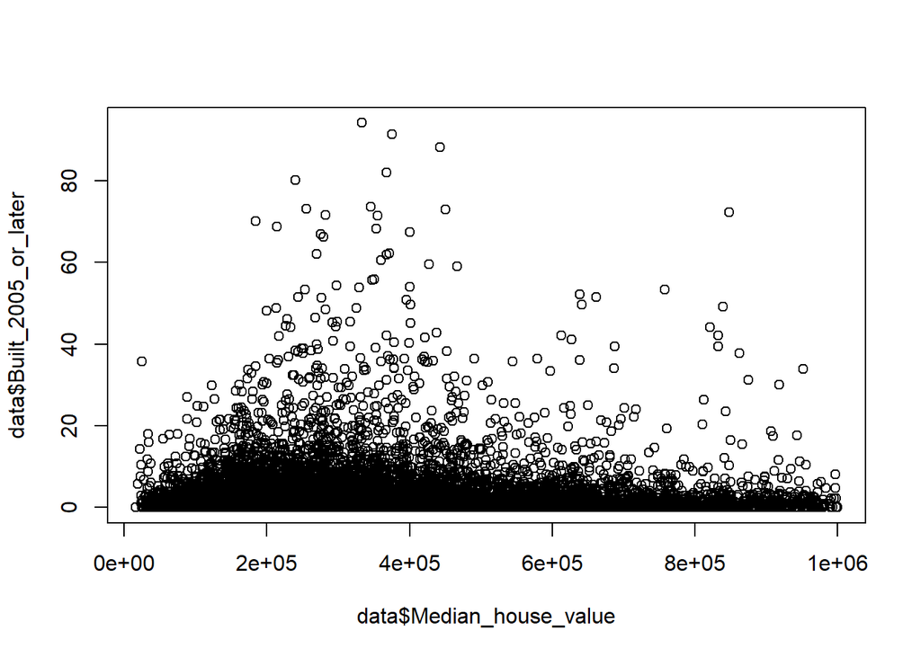

```r
scatter.smooth(data$Built_2005_or_later ~ data$Median_house_value)
```

- Постройте ещё два графика для каждого из штатов отдельно. Номер штата содержится в переменной (*STATEFP*), где Калифорния 6-й штат, а Пенсильвания 42.

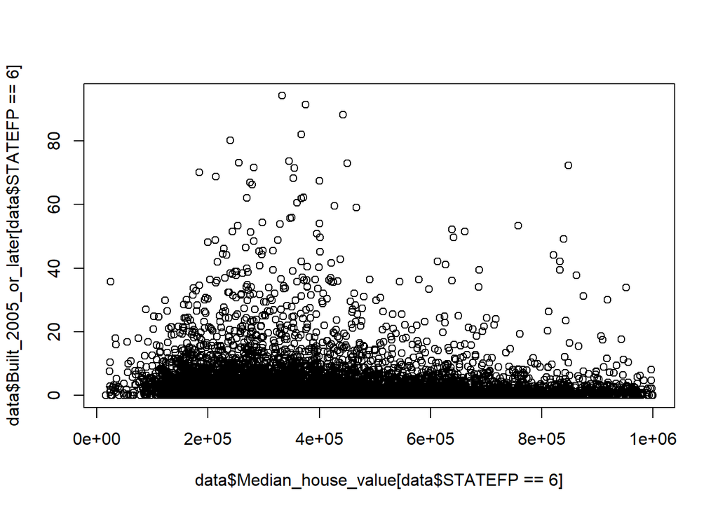

```r
scatter.smooth(data$Built_2005_or_later[data$STATEFP == 6] ~ data$Median_house_value[data$STATEFP == 6])
```

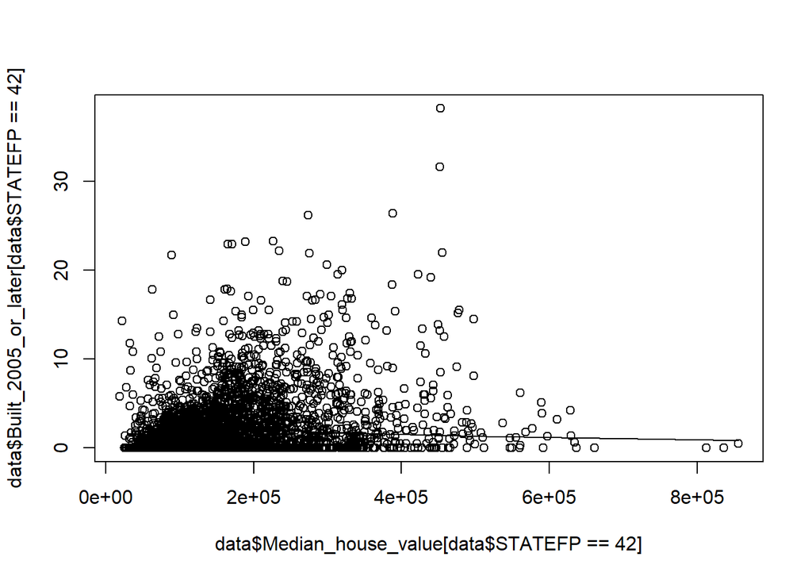

```r
scatter.smooth(data$Built_2005_or_later[data$STATEFP == 42] ~ data$Median_house_value[data$STATEFP == 42])
```

### Незанятые дома

Уровень найма (vacancy rate) — доля домов, которые не были заняты. В данных содержатся колонки, содержащие общее количество домовладений и количество не занятых домовладений. * В датафрейм *data* добавьте новую колонку *vacancy_rate*, которая должна содержать вышеописанный показатель.

```r
data$vacancy_rate <- data$Vacant_units/data$Total_units
```

- Найдите минимум, максимум, среднее и медиану полученных значений показателя.

```r
min(data$vacancy_rate)
```

```
## [1] 0
```

```r
max(data$vacancy_rate)
```

```
## [1] 0.965311
```

```r
mean(data$vacancy_rate)
```

```
## [1] 0.08888789
```

```r
median(data$vacancy_rate)
```

```
## [1] 0.06767283
```

- Постройте диаграмму уровня найма относительно медианы стоимости домов. Что можно заметить?

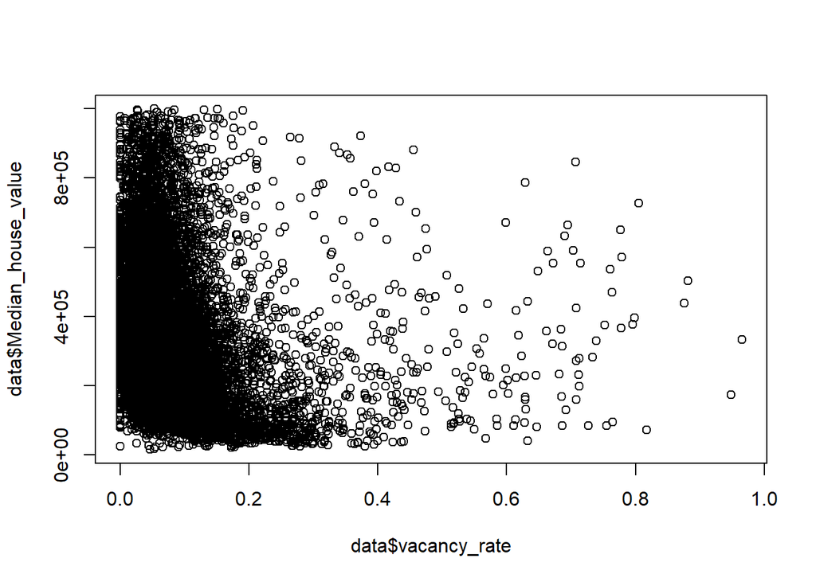

```r
plot(data$Median_house_value ~ data$vacancy_rate)
```

### Корреляция

Колонка *COUNTYFP* содержит числовой код округа внутри штата. Нас интересуют Butte County (округ 7 в Калифорнии), Santa Clara (округ 85 в Калифорнии) и York County (округ 133 в Пенсильвании). * Объясните, что делает приведённый в конце задания код и как именно он это делает.

```
Создаем пустой вектор
acc <- c()
Проходим по всем строчкам таблицы
for (tract in 1:nrow(ca_pa)) {
  Если штат Калифорния
  if (ca_pa$STATEFP[tract] == 6) {
    И округ Аламеда
    if (ca_pa$COUNTYFP[tract] == 1) {
      То добавляем в вектор номер строки
      acc <- c(acc, tract)
    }
  }
}
Создаем новый пустой вектор
accmv <- c()
Проходим по вектору строк, которые мы выбрали до этого
for (tract in acc) {
  Добавляем в вектор значение из десятого столбца (Median_house_value)
  accmv <- c(accmv, ca_pa[tract,10])
}
Считаем медиану по столбцу Median_house_value в округе Аламеда
median(accmv)
```

- Напишите другим способом в одну строку, то же самое, что делает нижеуказанный код. Способов получить тот же ответ множество, достаточно одного.

```r
median(data$Median_house_value[data$STATEFP==6][data$COUNTYFP==1],na.rm=TRUE)
```

```
## [1] 474050
```

- Найдите средний процент построенных домовладений в округах (Butte County, Santa Clara, York County)

```r
mean(data$Total_units[data$STATEFP == 6 & data$COUNTYFP == 7] / sum(data$Total_units[data$STATEFP == 6 ]), na.rm = TRUE)
```

```
## [1] 0.0001458294
```

```r
mean(data$Total_units[data$STATEFP == 6 & data$COUNTYFP == 85] / sum(data$Total_units[data$STATEFP == 6 ]), na.rm = TRUE)
```

```
## [1] 0.0001320997
```

```r
mean(data$Total_units[data$STATEFP == 42 & data$COUNTYFP == 133] / sum(data$Total_units[data$STATEFP == 42]), na.rm = TRUE)
```

```
## [1] 0.000360114
```

- Функция `cor` рассчитывает коэффициент корреляции между двумя переменными. Рассчитайте корреляцию между медианы стоимости домовладений (*Median_house_value*) и процентом построенных домов (*Built_2005_or_later*):
1. для всего набора данных

```r
cor(as.numeric(data$Built_2005_or_later), data$Median_house_value)
```

```
## [1] -0.01893186
```

2. для Калифорнии

```r
cor(as.numeric(data$Built_2005_or_later[data$STATEFP == 6]), data$Median_house_value[data$STATEFP == 6])
```

```
## [1] -0.1153604
```

3. для Пенсильвании

```r
cor(as.numeric(data$Built_2005_or_later[data$STATEFP == 42]), data$Median_house_value[data$STATEFP == 42])
```

```
## [1] 0.2681654
```

4. для округа Butte County

```r
cor(as.numeric(data$Built_2005_or_later[data$STATEFP == 6 & data$COUNTYFP == 7]), data$Median_house_value[data$STATEFP == 6 & data$COUNTYFP == 7], use = "pairwise.complete.obs")
```

```
## [1] 0.04203267
```

5. для округа Santa Clara

```r
cor(as.numeric(data$Built_2005_or_later[data$STATEFP == 6 & data$COUNTYFP == 85]), data$Median_house_value[data$STATEFP == 6 & data$COUNTYFP == 85], use = "pairwise.complete.obs")
```

```
## [1] -0.1726203
```

6. для округа York County

```r
cor(as.numeric(data$Built_2005_or_later[data$STATEFP == 42 & data$COUNTYFP == 133]), data$Median_house_value[data$STATEFP == 42 & data$COUNTYFP == 133], use = "pairwise.complete.obs")
```

```
## [1] 0.3860773
```

- Постройте три диаграммы медианы стоимости домовладений (*Median_house_value*) относительно медианы дохода (*Median_household_income*) для трёх округов. Допустимо указать все три на одном графике.

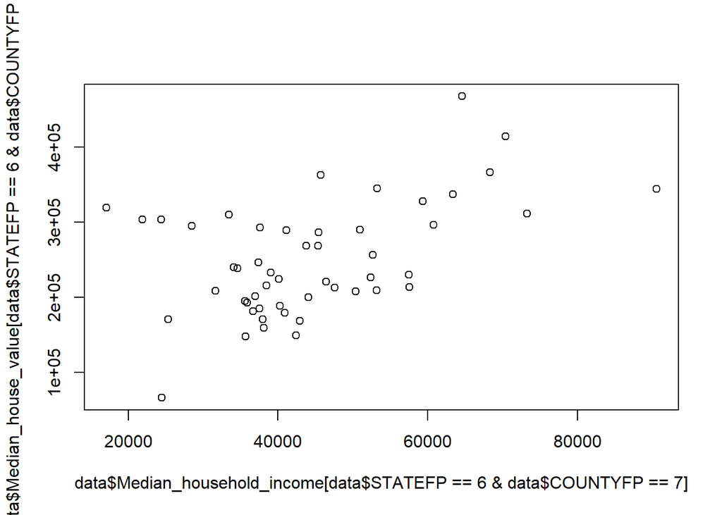

```r
plot(data$Median_house_value[data$STATEFP == 6 & data$COUNTYFP == 7] ~ data$Median_household_income[data$STATEFP == 6 & data$COUNTYFP == 7])
```

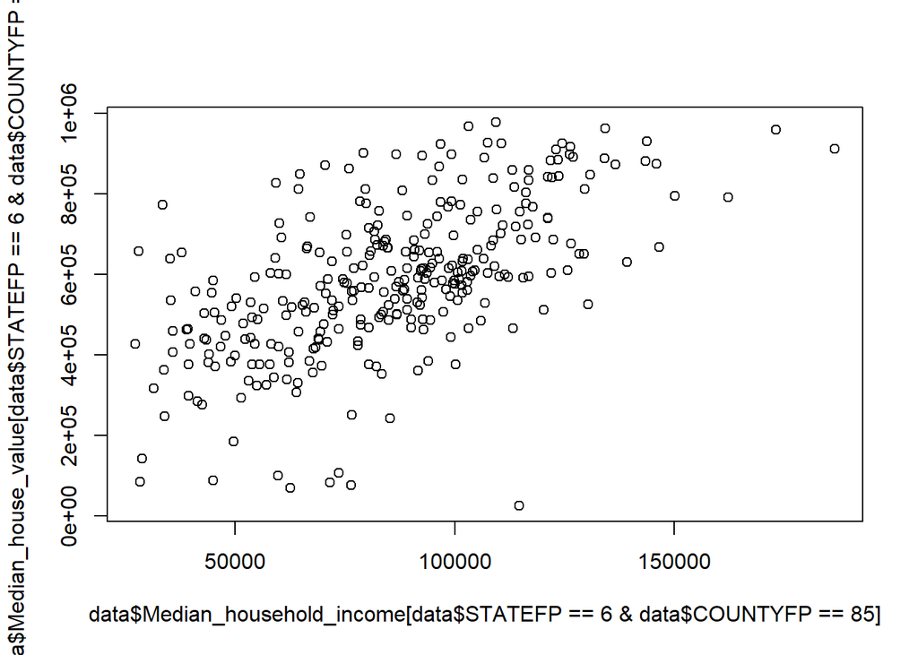

```r
plot(data$Median_house_value[data$STATEFP == 6 & data$COUNTYFP == 85] ~ data$Median_household_income[data$STATEFP == 6 & data$COUNTYFP == 85])
```

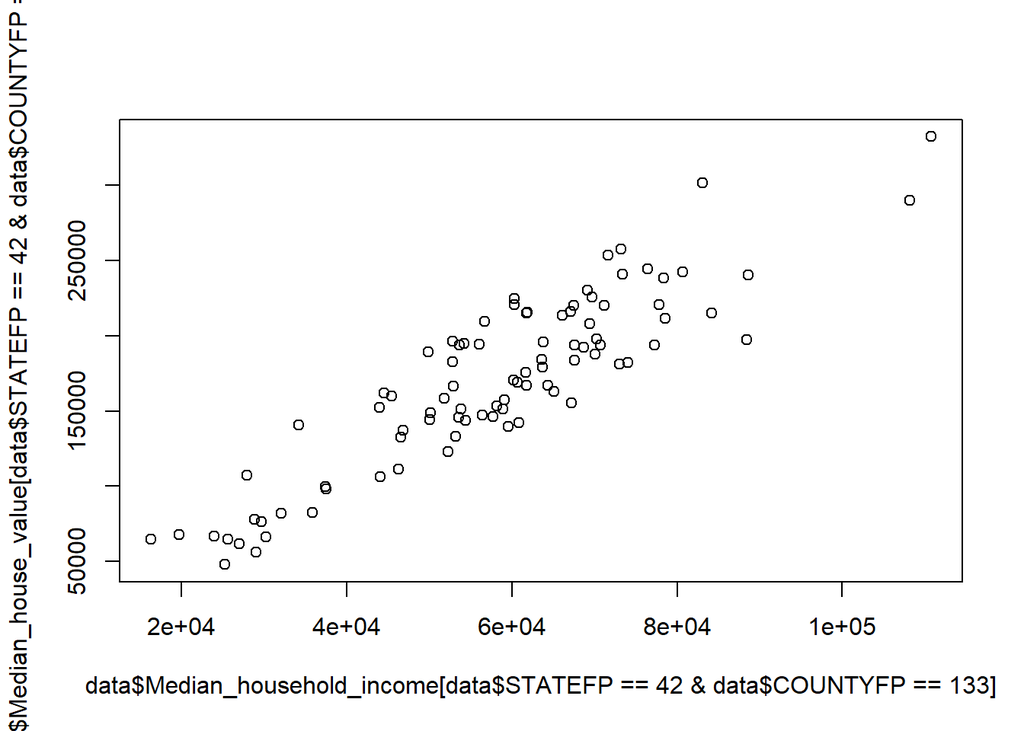

```r
plot(data$Median_house_value[data$STATEFP == 42 & data$COUNTYFP == 133] ~ data$Median_household_income[data$STATEFP == 42 & data$COUNTYFP == 133])
```